# Laboratorio 1.2: Exploración y Visualización de Datos

Marzo 2022

# Declaración de compromiso ético

Nosotros **Arturo Lazcano y Sebastián Cobaise**, declaramos que realizamos de manera grupal los pasos de la presente actividad. También declaramos no incurrir en copia, ni compartir nuestras respuestas con otras personas ni con otros grupos. Por lo que, ratificamos que las respuestas son de nuestra propia confección y reflejan nuestro propio conocimiento.

# Instrucciones

1. Trabajen en equipos de dos personas. Salvo excepciones, no se corregirá entregas con menos de dos integrantes.
2. Modifique este archivo `.Rmd` agregando sus respuestas donde corresponda.
3. Para cada pregunta, cuando corresponda, **incluya el código fuente que utilizó para llegar a su respuesta**.
4. El formato de entrega para esta actividad es un archivo html. **Genere un archivo HTML usando RStudio** y súbalo a U-Cursos.

Basta con que uno de los integrantes haga la entrega. Si ambos hacen una entrega en U-Cursos, se revisará cualquiera de éstas.

# Laboratorio

La primera parte de esta actividad son preguntas teóricas que avanzaron en las clases del curso de Minería de datos.

## Teoría

*1. ¿Cuál es la diferencia entre los atributos cualitativos y los cuantitativos? ¿Se puede transformar un atributo cuantitativo en cualitativo y viceversa? Ejemplifique.*

**Respuesta: Los atributos cualitativos corresponden a características del tipo etiquetas, valores representados con palabras, por ejemplo color de ojos, Si/No, Bueno/malo. En cambio, los cuantitativos son características expresadas en números, como una altura, temperatura, etc.**

**Sí es posible representar un atributo cualitativo como uno cuantitativo y viceversa, por ejemplo si un atributo se representa como (Bueno/Más o menos/Malo), esto se puede escribir como una nota del 1 al 3 (3/2/1) para que sea cuantitativo, otro ejemplo es que tengamos un atributo con la edad de personas, esta columna se puede agrupar en intervalos (Niño: 1-18/Adulto: 19-50/Adulto mayor:+51) lo cual pasaria a ser un atributo cualitativo**

*2. ¿Qué factores que ocasionan errores en el análisis de datos deben ser considerados para la limpieza de un set de datos? ¿Qué técnica estadística podría utilizar durante el proceso de limpieza? Ejemplifique con al menos una técnica.*

**Respuesta: Es importante tener en cuenta los datos faltantes de un dataset (ya sea eliminar esas filas o rellenarlos) y los datos outliers que se puedan detectar, por ejemplo para remover datos atípicos podemos remover los datos que sean demasiado grandes o muy pequeños (los que se encuentren fuera de un boxplot)**

*3. Describa dos medidas de tendencia central y explique sus posibles utilidades para el análisis exploratorio de datos.*

**Respuesta: La media y la moda son dos medidas de tendencia central muy usadas al intentar comprender los datos. Por una parte, la media es el promedio de los datos, esto es muy útil pues, dependiendo del caso, podemos trabajar solamente con este valor y no con todos los datos si es necesario, sin embargo, es sensible a valores atípicos. Por otro lado, la moda representa la categoría que mas se repite, es decir, la mayor frecuencia. Esto entrega una idea al usuario del comportamiento de los datos. Usualmente se acompaña con un histograma para poder comparar la categoría de mayor frecuencia con las distribuciones de los otros datos.**

*4. ¿Qué es una matriz de correlación y para qué sirve?*

**Respuesta: La matriz de correlación es una matriz que expresa la conexión entre variables, es decir, su relación entre ellas. Con esto se puede saber que variables crecen (o decrecen) cuando alguna otra cambia su valor. Un ejemplo es usar una correlación lineal, es decir, se obtiene una matriz con valores en [-1,1], donde el 1 indica una relación proporcional completa, el 0 una independencia lineal (no necesariamente variables independientes) y el -1 una relación inversa.**

*5. ¿Cuál es la utilidad de las visualizaciones en el análisis de datos? Ejemplifique.*

**Respuesta: La visualización de datos es importante en el análisis pues grafica y facilita el entendimiento de los datos para el usuario, pudiendo observar patrones o tendencias en estos. Un ejemplo sería usar histogramas, pudiendo saber de forma inmediata la categoría más repetida junto con una pequeña idea en como se compara con las otras.**

## Práctica

### Accidentes de tránsito

Para esta sección utilizaremos un dataset real de número de accidentes de tránsito por localidad, el cual puede ser encontrado en el siguiente link: http://datos.gob.cl/dataset/9348. Para cargar el dataset ejecute el siguiente código:

```r
tipos <- read.table("https://users.dcc.uchile.cl/~hsarmien/mineria/datasets/accidentes_2010_2011.txt")
head(tipos)
```

```
##    Muestra                   Descripcion Anio TipoAccidente Cantidad
## 1 Nacional                      Nacional 2010     Atropello     8247
## 2 Nacional                      Nacional 2011     Atropello     8339
## 3 Regional XV RegiÃ³n Arica y Parinacota 2010     Atropello      115
## 4 Regional XV RegiÃ³n Arica y Parinacota 2011     Atropello      159
## 5  Comunal                         ARICA 2010     Atropello      115
## 6  Comunal                         ARICA 2011     Atropello      158
```

Explore el set de datos para responder las siguientes preguntas:

1. ¿Cuáles son las dimensiones del dataset (filas, columnas)? (Recuerde adjuntar código).

```r
# RESPUESTA: Hay 4296 filas y 5 columnas
dim(tipos)
```

```
## [1] 4296    5
```

2. ¿Qué describe cada línea del dataset? (ejemplifique tomando el dato de la fila 235, extienda la descripción)

```r
# RESPUESTA

#Cada fila corresponde a un registro de accidentes de un lugar.
#Muestra corresponde a la escala del lugar (por ejemplo Nacional o Regional, etc)
#Descripción especifica el lugar
#Anio es el año del registro
#TipoAccidente es la clase de percance ocurrido
#Cantidad es las veces que ocurrió dicho suceso
#Por ejemplo, la fila 235 corresponde a ocurrieron 4 atropellos en la Comuna de Palmilla el 2010
tipos[235,]
```

```
##     Muestra Descripcion Anio TipoAccidente Cantidad
## 235 Comunal    PALMILLA 2010     Atropello        4
```

3. ¿Cuántos años diferentes abarca la información el dataset? Entregue una tabla que contenga los valores únicos que hay en la columna Anio.

```r
# RESPUESTA hay solo 2 años: 2010 y 2011
unique(tipos[c("Anio")])
```

```
##   Anio
## 1 2010
## 2 2011
```

4. Filtre los datos y genere un dataframe en el cual se indique la cantidad de accidentes tipo `Colision` que ocurrieron en el año `2011` y que no sean de la muestra `Nacional`.

```r
# RESPUESTA
coli=tipos[tipos$Anio == 2011 & tipos$Muestra != "Nacional" & tipos$TipoAccidente == "Colision", ]
head(coli)
```

```
##       Muestra                   Descripcion Anio TipoAccidente Cantidad
## 1436 Regional XV RegiÃ³n Arica y Parinacota 2011      Colision      426
## 1438  Comunal                         ARICA 2011      Colision      414
## 1440  Comunal                     CAMARONES 2011      Colision        6
## 1442  Comunal                         PUTRE 2011      Colision        6
## 1444  Comunal                 GENERAL LAGOS 2011      Colision        0
## 1446 Regional        I RegiÃ³n de TarapacÃ¡ 2011      Colision      416
```

5. Filtre los datos para incluir sólo los accidentes ocurridos el año 2010 a nivel regional. Genere un boxplot donde se indique la cantidad de accidentes categorizado por tipo de accidente.

Este tipo de gráfico nos ayudará a entender como se distribuye los datos por cada tipo de accidentes. Es decir, podremos apreciar que tan dispersos o similares son los datos en todo el dataset. También, puede ser útil para observar valores atípicos u outliers en los datos.

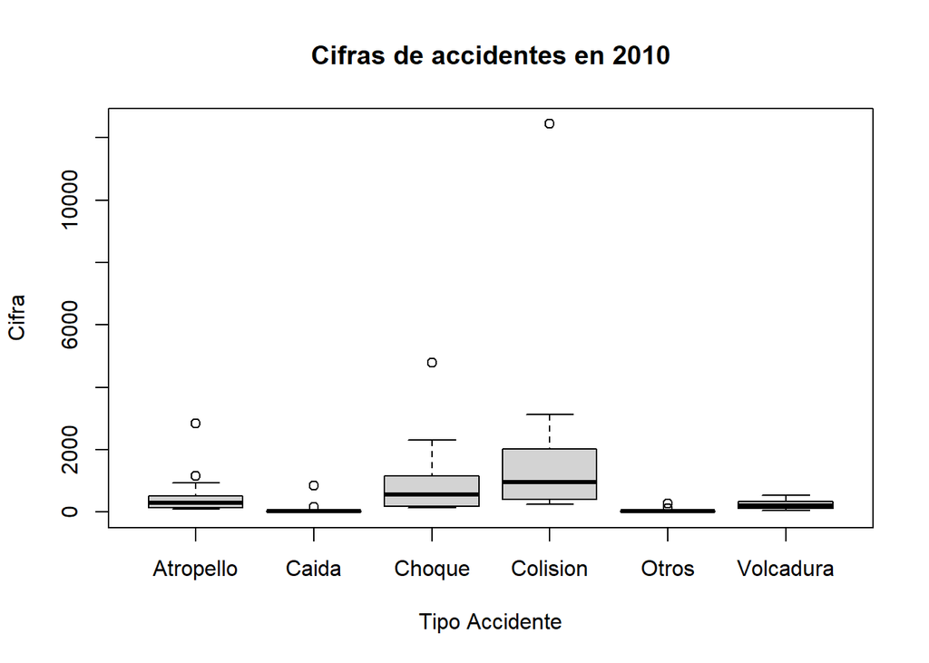

```r
# RESPUESTA
anio2010=tipos[tipos$Anio == 2010 & tipos$Muestra == "Regional", ]
boxplot(anio2010$Cantidad~anio2010$TipoAccidente,ylab="Cifra",xlab="Tipo Accidente",main="Cifras de accidentes en 2010")
```

6. ¿Qué otra forma de explorar los datos podría agregar para el dataset de Accidentes de tránsito y qué información adicional aporta? Adjunte el código necesario.

```r
# RESPUESTA podemos agrupar por región para obtener información sobre cada región por separado
#esto nos puede aportar información sobre las regiones con mayor cantidad de accidentes

library("tidyverse")
```

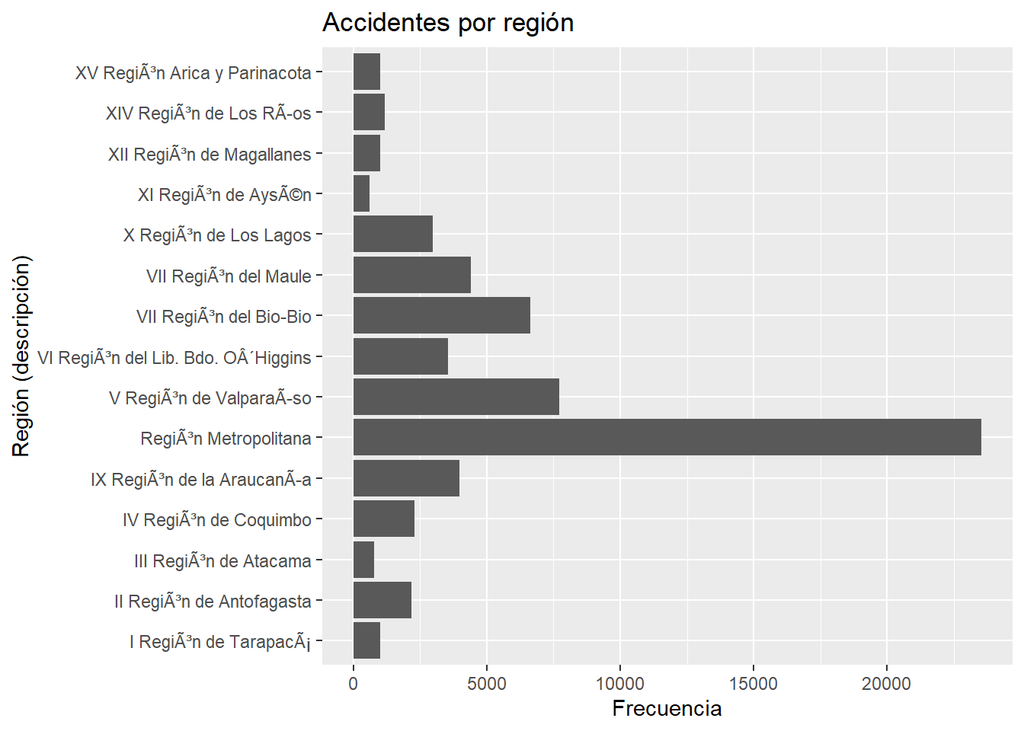

```r
regiones <- tipos %>%
  filter(Anio == 2011 & Muestra == "Regional") %>%
  group_by(Descripcion) %>%
  summarise(total = sum(Cantidad)) %>%
  arrange(-total)

library(ggplot2)  # cargamos la librería

ggplot(regiones) +
  geom_bar(aes(x = Descripcion, y = total), stat="identity") +
  coord_flip() +
  ggtitle("Accidentes por región") + # título
  xlab("Región (descripción)") + ylab("Frecuencia")  # etiquetas
```